# A Standard for the Scholarly Citation of Archaeological Data

Ben Marwick

Suzanne E. Pilaar Birch

07 September, 2017

Abstract

# 1 Introduction

The goal of this paper is to present a standard for the scholarly citation of archaeological data, akin to the way we cite publications. The need for this has been motivated by Huggert’s (2017) findings of low levels of data citation and reuse in archaeology, and Clarke’s (2015) analysis that digital data preservation and management systems are under-developed in archaeology, despite our obligations as stewards of cultural heritage. A standard for data citation is important because it gives credit to the authors or compilers of the data, and so accords them visibility and recognition for their scholarly contribution in a way that is valued broadly in the discipline. A citation standard is also important for tracking the use of the data, and generating metrics about the impact of the dataset on the discipline. Understanding the use of resources such as datasets is important for allocating resources within the discipline and identifying novel research directions.

We will start by defining what we mean by ‘data’, and reviewing previous work on researchers’ attitudes to sharing data. We motivate data sharing and citing behaviours by explaining why data sharing is beneficial to archaeology as a discipline, and to individual researchers. Then we will survey some of the data sharing and citing norms that have emerged in other research areas. From these norms we will present a standard suitable for citation of archaeological data. Finally, we will present some basic instructions on how to share archaeological data.

# 2 What are data?

“The term “data” as used in this document is meant to be broadly inclusive. In addition to digital manifestations of literature (including text, sound, still images, moving images, models, games, or simulations), it refers as well to forms of data and databases that generally require the assistance of computational machinery and software in order to be useful, such as various types of laboratory data including spectrographic, genomic sequencing, and electron microscopy data; observational data, such as remote sensing, geospatial, and socioeconomic data; and other forms of data either generated or compiled, by humans or machines.” (Uhlir & Cohen, 2011)

# 3 What are the benefits of data sharing to the individual researcher?

# 4 What do researchers think about sharing data?

# 5 What are the current norms of data sharing?

The surveys above show that data sharing practices tend to be a private activity, but where public sharing does occur, what forms does it take, and how to these vary across different fields of research? Wouters and Haak (2017) surveyed 1,200 researchers about data sharing behaviours and found a spectrum from ‘intensive data-sharing fields’ to ‘restricted data-sharing fields’. Intensive data-sharing fields often depend on access to global databases, for example human genetics, while restricted data-sharing fields depend mostly on data collected by the individual researcher or their immediate collaborators, such as digital humanities. These differences in disciplinary norms have implications for data ownership (intensive: collectively owned, willing to share; restrictive: owned by the individual, reluctant to share) and the effort required to share (intensive: low effort because data are prepared for sharing as an integral part of the research process, restrictive: high effort because data are prepared for sharing after the research, or apart from it, in response to a request from another researcher). Archaeologists can be found all over this spectrum because of the diversity of archaeological research, however, our view is that archaeology is for the most part a restricted data-sharing field. There are few standardised and widely used methods for sharing and citing data, a challenge for archaeological data sharing that we hope this paper will help to address.

Even though there is a wide spectrum of data sharing behaviours, from intensive to restrictive, overall rates of data sharing are very low in many fields. Wicherts et al. (2006) emailed authors of 141 empirical articles recently published by the American Psychological Association (APA) journals to request a copy of the original data reported in the articles. They received 64 of the 249 datasets they requested, resulting in a data sharing rate of about 26%, despite all the authors of the articles in their study being bound to the APA’s Ethical Principles, which state authors must ‘not withhold the data on which their conclusions are based from other competent professionals who seek to verify the substantive claims’ (American Psychological Association, 2001, p. 396). Valpaemel et al. (2015) similarly requested data from 394 papers, published in all issues of four APA journals in 2012 and found that 38% of authors responded with their data. They concluded that although the data sharing rate increased as compared to the study by Wicherts et al., their findings are ‘worrisome’ and indicate a ‘poor availability of data’.

Savage and Vickers (2009) requested data from authors of ten papers published in PLOS journals, and received only one reply. Although this is a very small sample, it is notable because PLOS journals require authors to share data as a condition of publication: “PLOS journals require authors to make all data underlying the findings described in their manuscript fully available without restriction, with rare exception.” (PLoS Medicine Editorial and Publishing Policies nd), and yet only one out of the ten authors actually complied with this requirement. Alsheikh-Ali et al. (2011) inspected 500 articles published in high-impact science journals in 2009 and found that only 47 papers (9%) deposited full primary raw data online. Similarly, Womak (2015) inspected 4,370 articles published in high-impact science journals in 2014 and found that 13% of articles with original data published make the data available to others.

The absence of a standardised and sustainable approach to data sharing is starkly demonstrated by Vines et al.’s (2014) study of data availability over time in biology publications. They examined the availability of data from 516 studies of plants or animal morphology between 2 and 22 years old. Vines et al. found that odds of a data set referred to in a publication being available fell by 17% per year. The found that the key factors responsible for the unavailability of data was that the data were lost or on inaccessible storage media.

# 6 Do archaeologists share data?

Here we present the results of three small pilot studies aimed at understanding how archaeologists share their data. First, we emailed a sample of authors of research publications to request access to the data behind their publication. Second, we surveyed a sample of journal articles to see what data was available. Third, we analysed information about archaeological data files in online repositories tracked by DataCite (an organisation that provides persistent identifiers, or DOIs for research data).

## 6.1 Email requests for data in a published article

Our sample focused on *Journal of Archaeological Science* articles on experiments with stone artefacts that were published during 2009 and 2015. We focused on stone artefact experiments because the all research materials in these projects are generated by the researcher, so there are no other stakeholders to consider when determining how to share the data: the researcher has complete control over the data. There are also no risks of damage to people or property in sharing these data because they do not include archaeological sites or human subjects. In contacting the authors, we requested the datasets for use in a graduate seminar with the aim of reproducing the published results and further exploring the data (this stage is still in progress). We promised to contact the authors if we discovered anything new, and not to share the data further without their permission. The data included with this paper is anonymised so the specific authors we contacted are not identifiable.

Similarly there are no clear patterns data sharing of among different journals. It is remarkable that the authors of the one PLOS One paper we contacted declined to share because that refusal violates the policy of that journal at the time of publication of that paper (early 2014): “Publication is conditional upon the agreement of the authors to make freely available any materials and information described in their publication that may be reasonably requested by others for the purpose of academic, non-commercial research.” Chambers’ (2017) examined 50 PLOS One papers on brain images published in November 2014 - May 2015 and found that only 38% of these papers archived their data in an open repository. Similarly, Nuijten et al. (2017) found that of 462 PLOS One articles that promised data availability, 29% of these did not have any available data. Unfulfilled promised to share data are not unique to PLOS One (Kidwell et al. 2016), but these studies highlight the need to resolve ambiguity among authors about what counts as data, and for editors and peer reviwers to more critically assess whether an author has been made their data openly available.

We see similar rates of sharing in response to email requests among archaeologist to what have been described in other disciplines (Tenopir et al. 2015; Vanpaemel et al. 2015). However, our result may overestimate the true rate because our sample did not include datasets that authors might not be able or willing to share because they contain sensitive location or cultural information. Analysis of the qualitative responses suggests two key reasons why author are reluctant to share: they are fearful that they will lose the opportunity to produce further publications from those data, and that their data is not in a form suitable for sharing and the task of organising those data is not a high priority. These reasons not to share have also been documented in other research areas. The absence of patterns in the date of the paper, student status of the author and other variables may relate to more to our small sample size than a real absence of relationships in data sharing behaviour.

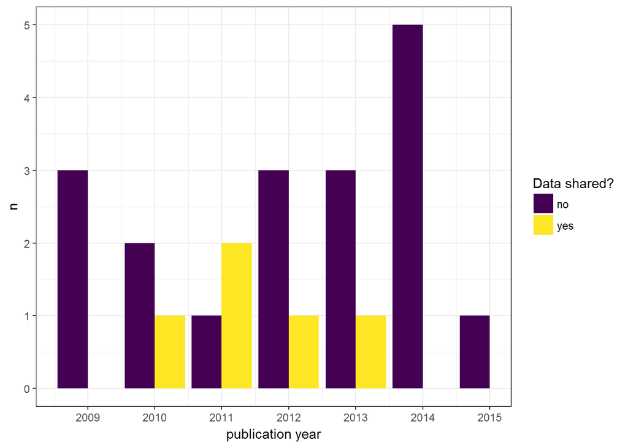

Figure 6.1: There is no obvious trend in data sharing becavious and date of publication

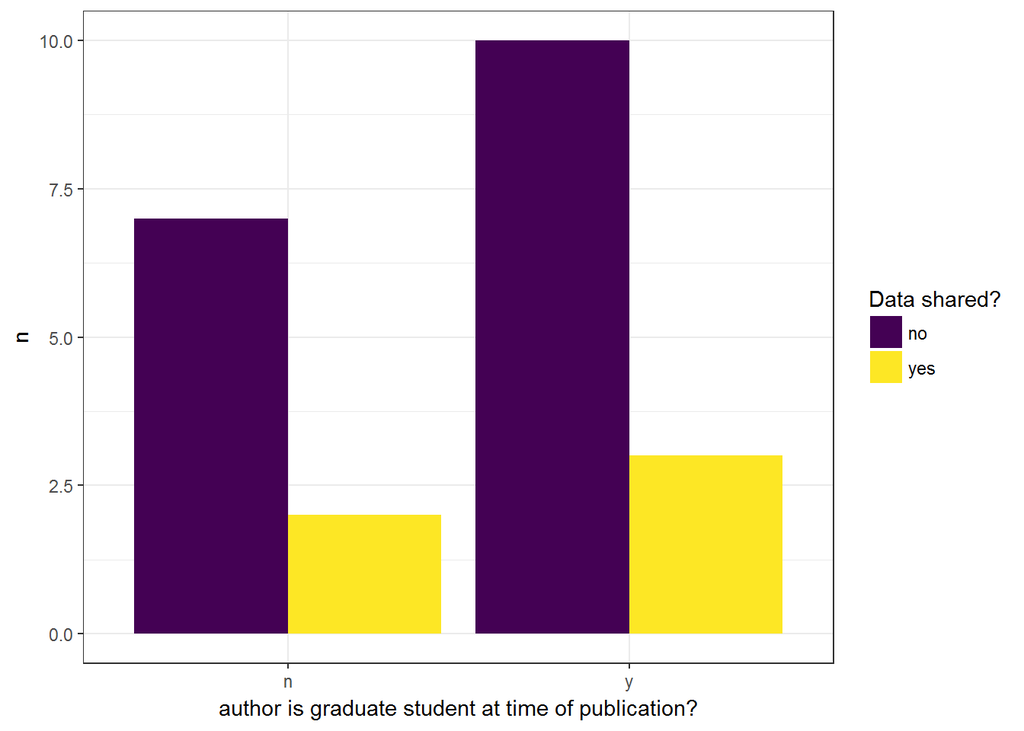

Figure 6.2: No relationship between student status and data sharing behaviour

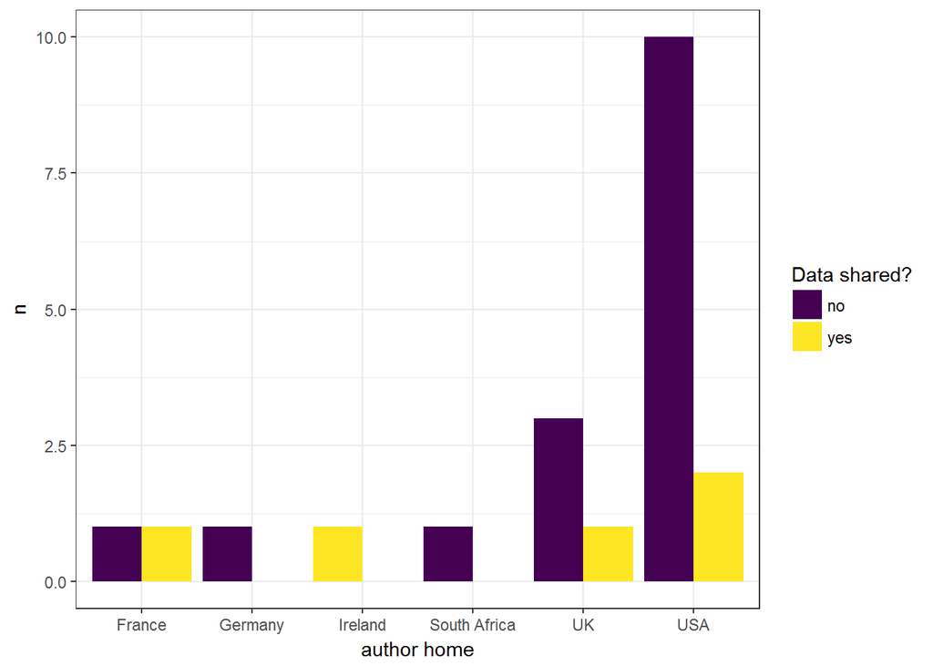

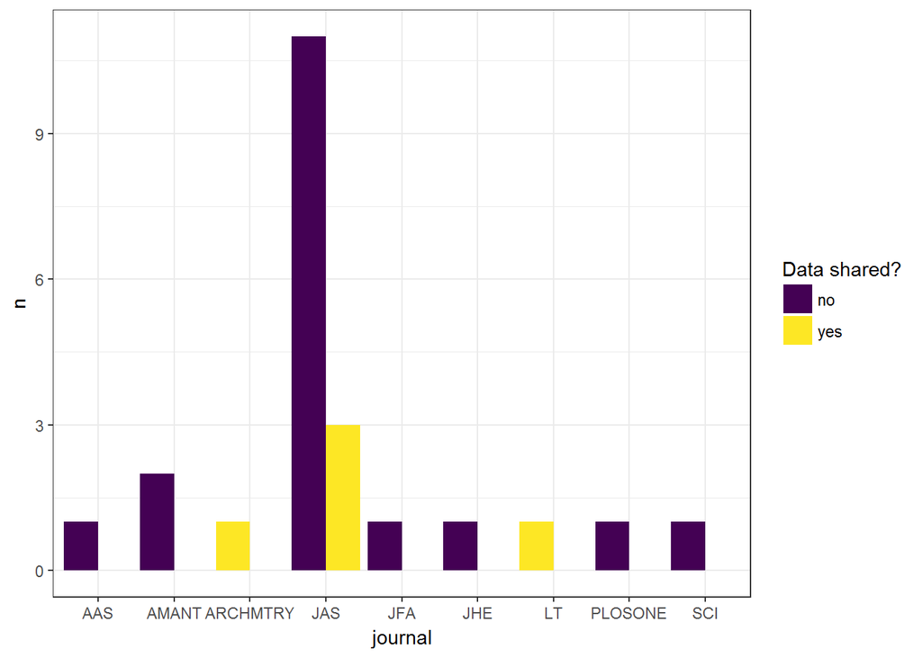

Figure 6.3: No relationship between sharing behaviour and journal.

## 6.2 Survey of articles published in the *Journal of Archaeological Science*

The *Journal of Archaeological Science* has had a ‘data disclosure’ policy since at least 2013 (Editors, 2013) which states that “All data relating to the article must be made available in Supplementary files or deposited in external repositories and linked to within the article”. The data availability rate of 53% reported in our pilot study reflects either weak enforcement of this policy or an incomplete understanding among editors and authors of how to interpret and implement this policy. The prominence of compositional and dating data among the shared data types suggests a least effort strategy by authors sharing data that do not require extensive cleaning and tidying (because the data are generated by instrumented rather than entered by hand, such as artefact attribute data). The size of compositional and dating datasets means that they mostly fit easily into tables in the text or supplementary files, and do not require much effort to organise (e.g. very little metadata is required for others to use these data). The small proportion of papers in our sample using or sharing a scripting language suggests that unlike other fields (Eglen et al. 2017), archaeologists do not appear to recognise code for data analysis as a primary research object to share with the research community.

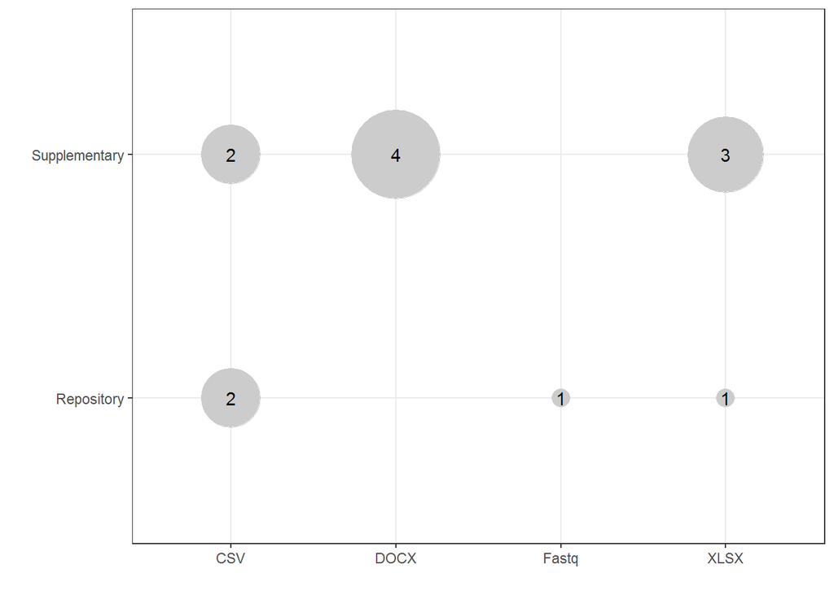

Figure 6.4: No relationship between data file type and data sharing location

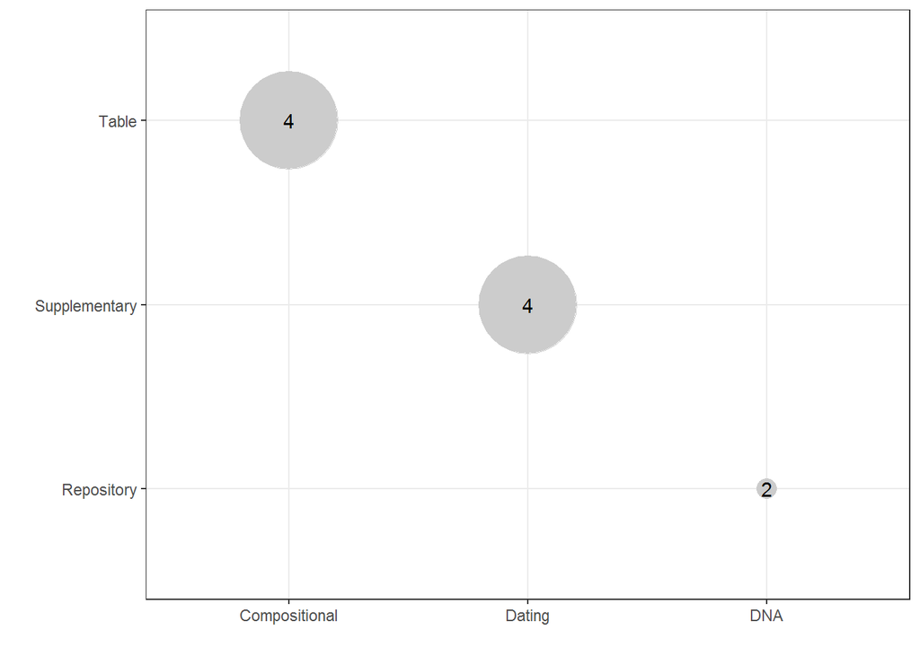

Figure 6.5: Plot of the relationship between data type and location where it is shared.

## 6.3 Data sets in repositories tracked by DataCite

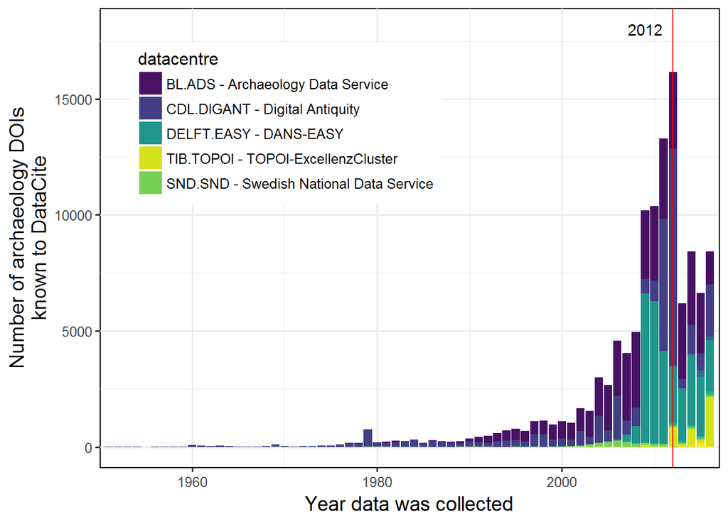

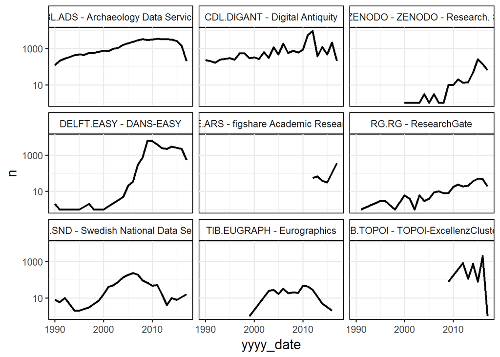

Of the 75,632 records with copyright information, the majority are released under the ADS conditions of use (n = 43,661, 58%), which is broadly similar to the CC-BY-NC (Moore and Richards 2015). The next most frequently used condition is the EU Open Access licence (n = 22,198, 29%), similar to the CC-BY licence. Creative Commons licenses such as CC-BY, CC-0 and others are used by less than 3% of records.

Many of the records are grey literature such as unpublished reports, produced by commercial consultants or research projects. Of the 66,121 (56%) records that include information about the file types in the deposit, 86% (n = 56,935) contain only PDFs. Structured data files such as spreadsheets, databases or shapefiles are found either alone or together with other file types (typically PDFs) in 7% (n = 4,481) records. The highest proportion of records with structured data files are found in the DANS-EASY repository (n = 4,304, 14%), followed by the ADS with 0.4% (n = 174). Note that we do not have any file format information for all the records from some smaller repositories in this sample, so it is possible that the true proportion of structured files in these records is higher.

From this pilot study of repository data we see that policy mandates in the UK and the Netherlands have been effective in populating repositories with archaeological data. With the 2012 spike in records deposited in tDAR we also see that archaeologists are sensitive to the price of sharing data. Nearly all records are made available under conditions that permit others to use the data while requiring that the original author of the data receive credit in reuse. In most cases this is because the repository hosting the data requires the author to choose one of these permissive licenses as a condition of making the deposit. However, although many items are *able* to be reused because of the licenses, then ease of reuse of these items is low. Only a small fraction of the items deposited are machine-readable structured data files. The majority of items are PDFs, which require extensive manual handling to extract tablular data for convenient reuse and combination with other datasets.

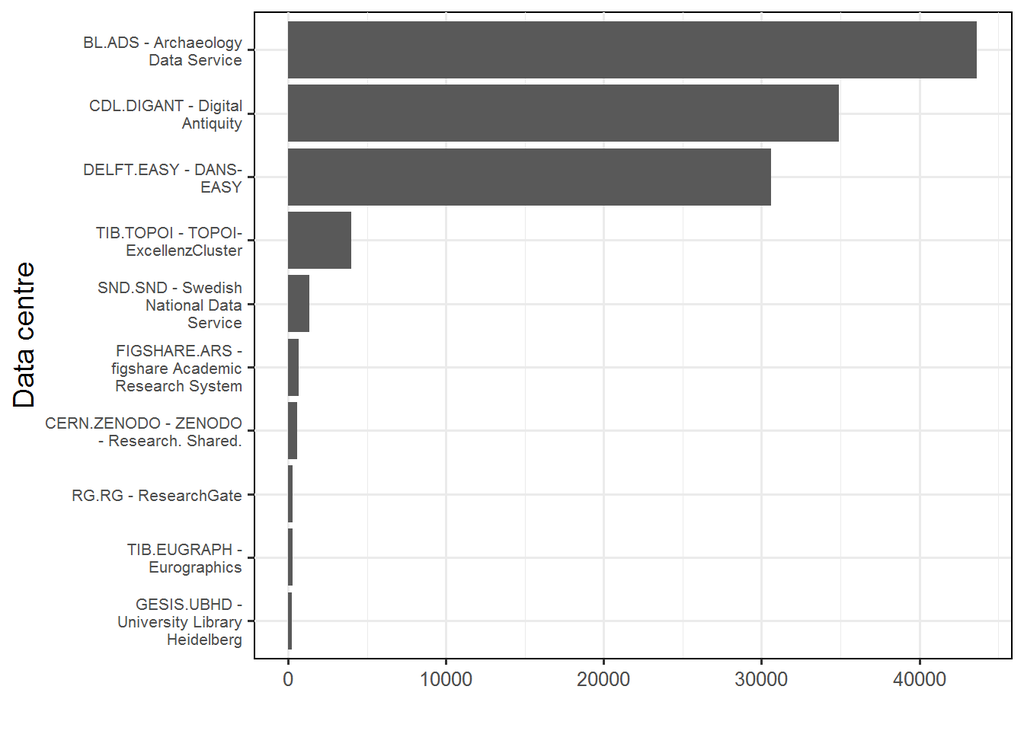

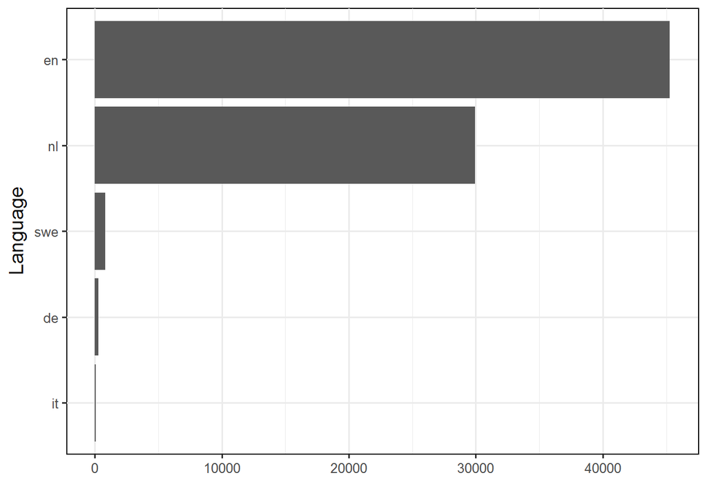

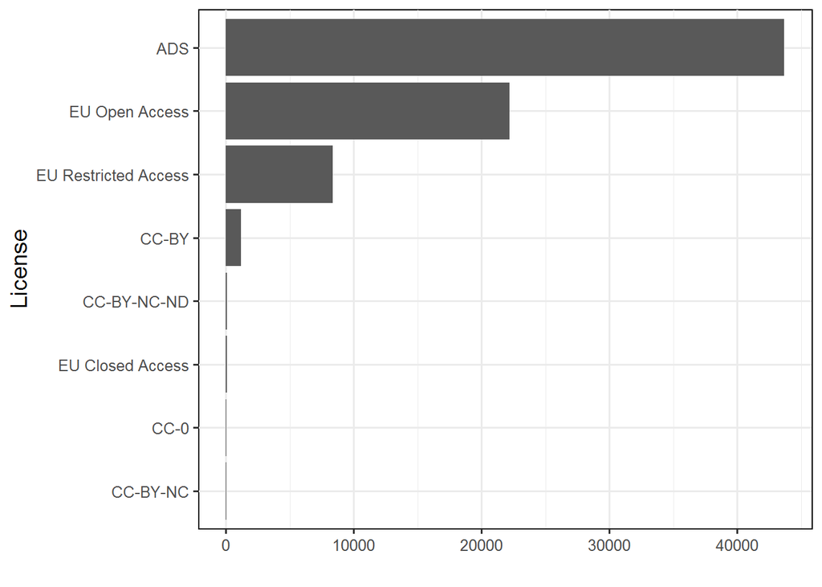

[figure not shown]

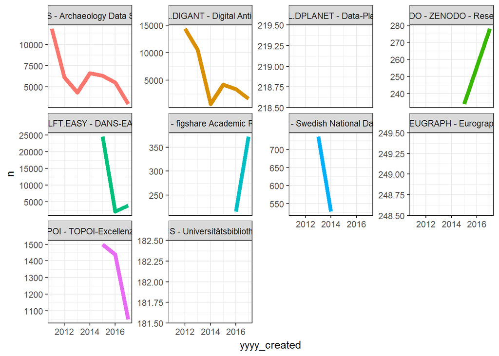

# 7 How to share archaeological data?

Data sharing is a relatively new behaviour for most archaeologists, so it is important to clarify what does not count as data sharing. Making data available on a web site that is not a trustworthy, persistent-identifier-issuing repository is not data sharing. For example, data files hosted on a personal faculty webpage or the web server of a research project is problematic because these files could disappear at any tim, the data can change in untracked ways, and published links to the files are broken when these websites are reorganised, making the files inaccessible. Sharing data via supplementary files attached to a journal article is problematic because the are inaccessible to non-subscribers for paywalled journals, and because publishers often alter the data file formats and and file names during the production process. For example, machine-readable format such as CSV are sometimes presented as PDF or Microsoft Word files in supplementary files. The modification of supplementary file names during the article production process can break scrips that attempt to read files by referring to file names as they were prior to the publisher handling the files. Finally, authors who write in their publications that ‘the data are available by request’ are not sharing data. Not only are the data not actually available, but there is no way to enforce that the authors will actually honour any requests for their data. A simple strategy for avoiding these pseudo-sharing behaviours is to deposit data files in a trustworthy data reposity, and link to the files in reports and manuscripts.

# 8 How to cite archaeological data?

# Ethical limitations to data sharing

# 9 Summary

# 10 Acknowledgements

This paper emerged out of discussions at the 2017 SAA meeting, specifically the forum ‘Beyond Data Management: A Conversation about “Digital Data Realities”’, organised by Sarah Kansa and Eric Kansa, and the SAA publications committee meeting.

# 11 References

Alsheikh-Ali AA, Qureshi W, Al-Mallah MH, Ioannidis JPA (2011) Public Availability of Published Research Data in High-Impact Journals. PLOS ONE 6(9): e24357. https://doi.org/10.1371/journal.pone.0024357

American Psychological Association. (2001).Ethical standards for the reporting and publishing of scientiﬁc information. In Publication manual of the American Psychological Association (5th ed., pp. 387–396). Washington, DC

ARCHES project. (n.d.). The Standard and Guide to Best Practice in Archaeological Archiving in Europe. Retrieved September 7, 2017, from http://archaeologydataservice.ac.uk/arches/Wiki.jsp?page=ARCHES%20Introduction

Bierer, B.E., Crosas, M., Pierce, H.H., 2017. Data Authorship as an Incentive to Data Sharing, New England Journal of Medicine.

Borgman, C. L. (2012). The conundrum of sharing research data. Journal of the American Society for Information Science and Technology, 63(6), 1059–1078. doi:10.1002/asi.22634

Chambers, C. (2017). The seven deadly sins of psychology: A manifesto for reforming the culture of scientific practice. Princeton, NJ: Princeton University Press.

Clarke, Mary. 2015. “The Digital Dilemma: Preservation and the Digital. Archaeological Record.” Advances in Archaeological Practice. 3(4): 313-330.

Daston, Lorraine, Galison Peter. (1992) The Image of Objectivity. Representations. 40:81–128.

Dorch, B. F., Drachen, T. M., & Ellegaard, O. (2015). The data sharing advantage in astrophysics. Proceedings of the International Astronomical Union, 11(A29A), 172-175.

Editors, (2013). Guide for Authors. Journal of Archaeological Science. Retrieved from https://web.archive.org/web/20130125222940/https://www.elsevier.com/journals/journal-of-archaeological-science/0305-4403/guide-for-authors

Ellison, L. A. (2012). Just 20 days left!! Upload your archaeological information FREE to tDAR!! | The Digital Archaeological Record. Retrieved September 7, 2017, from https://www.tdar.org/news/2012/12/just-20-days-left-upload-your-archaeological-information-free-to-tdar/

Eglen, S. J., Marwick, B., Halchenko, Y. O., Hanke, M., Sufi, S., Gleeson, P., Poline, J.-B. (2017). Toward standard practices for sharing computer code and programs in neuroscience. Nature Neuroscience, 20(6), 770–773. https://doi.org/10.1038/nn.4550

Gleditsch, N. P., Metelits, C., & Strand, H. (2003). Posting your data: will you be scooped or will you be famous. International Studies Perspectives, 4(1), 89-97.

Hart EM, Barmby P, LeBauer D, Michonneau F, Mount S, et al. (2016) Ten Simple Rules for Digital Data Storage. PLOS Computational Biology 12(10): e1005097. doi: 10.1371/journal.pcbi.1005097

Henneken, E. A., & Accomazzi, A. (2011). Linking to data-effect on citation rates in astronomy. arXiv preprint arXiv:1111.3618.

Huggett, J. (2017, May 23). Citing Data Reuse. Retrieved from https://introspectivedigitalarchaeology.wordpress.com/2017/05/23/citing-data-reuse/

Inter-university Consortium for Political and Social Research (ICPSR). (2012). Guide to Social Science Data Preparation and Archiving: Best Practice Throughout the Data Life Cycle (5th ed.). Ann Arbor, MI

Kidwell, M. C., Lazarević, L. B., Baranski, E., Hardwicke, T. E., Piechowski, S., Falkenberg, L. S., … & Errington, T. M. (2016). Badges to acknowledge open practices: A simple, low-cost, effective method for increasing transparency. PLoS Biol, 14(5), e1002456.

Keers, G., van der Reijden, H., and van Rossum, H. 2011. Planning Archaeology: A Synthesis of the Thematic Sub-reports. Amsterdam: Rigo.

Kratz JE, Strasser C (2015) Researcher Perspectives on Publication and Peer Review of Data. PLOS ONE 10(2): e0117619. doi: 10.1371/journal.pone.0117619

Kratz, J., Strasser, C., 2014. Data publication consensus and controversies, F1000Research 3.

Leonelli, S. (2016). The philosophy of data, In Floridi, L. (Ed.) The Routledge Handbook of Philosophy of Information. Routledge.

Merton, R.K. (1942) “The Normative Structure of Science”. In: Merton, R. K., The Sociology of Science: Theoretical and Empirical Investigations, Chicago, IL: University Of Chicago Press.

Moore, R., & Richards, J. (2015). Here Today, Gone Tomorrow: Open Access, Open Data and Digital Preservation. In Andrew T. Wilson, Ben Edwards (eds) Open Source Archaeology: Ethics and Practice. De Gruyter, Netherlands

Nichols, D.M., Twidale, M.B., 2017. Metrics for openness, Journal of the Association for Information Science and Technology 68, 1048-1060.

Nuijten, M. B., Borghuis, J., Veldkamp, C. L. S., Alvarez, L. D., van Assen, M. A. L. M., & Wicherts, J. M. (2017, July 13). Journal Data Sharing Policies and Statistical Reporting Inconsistencies in Psychology. Retrieved from psyarxiv.com/sgbta

National Science Board. (2005). Long-lived digital data collections. Retrieved from http://www.nsf.gov/pubs/2005/nsb0540/

National Science Foundation. (2010). Data Management & Sharing Frequently Asked Questions (FAQs). Retrieved from https://www.nsf.gov/bfa/dias/policy/dmpfaqs.jsp#1

National Science Foundation. (2016). Dissemination and Sharing of Research Results. Retrieved from https://www.nsf.gov/bfa/dias/policy/dmp.jsp

Piwowar HA, Day RS, Fridsma DB (2007) Sharing Detailed Research Data Is Associated with Increased Citation Rate. PLOS ONE 2(3): e308. https://doi.org/10.1371/journal.pone.0000308

Piwowar, H. A., & Vision, T. J. (2013). Data reuse and the open data citation advantage. PeerJ, 1, e175.

PLoS Medicine Editorial and Publishing Policies. 13. Sharing of Materials, Methods and Data. PLoS Medicine Editorial and Publishing Policies. Available from: http://journals.plos.org/plosmedicine/policies.php#sharing.

Rowhani-Farid, A., Allen, M., & Barnett, A. G. (2017). What incentives increase data sharing in health and medical research? A systematic review. Research Integrity and Peer Review, 2(1), 4. https://doi.org/10.1186/s41073-017-0028-9

Sears, J.R.L (2011) Data sharing effect on article citation rate in paleoceanography. Presented at Fall Meeting of the American Geophysical Union. https://doi.org/10.6084/M9.FIGSHARE.1222998.V1

Strasser, C., Cook, R., Michener, W., & Budden, A. (2012). Primer on Data Management: What you always wanted to know. EScholarship. https://doi.org/10.5060/D2251G48

Stodden, V. (2009a). The legal framework for reproducible scientific research: Licensing and copyright. Computing in Science & Engineering, 11(1), 35-40.

Stodden, V. (2009b) Enabling Reproducible Research: Open Licensing for Scientific Innovation. International Journal of Communications Law and Policy. Available at SSRN: https://ssrn.com/abstract=1362040

Stodden, V. 2010, The Scientific Method in Practice: Reproducibility in the Computational Sciences, Columbia University Academic Commons, http://hdl.handle.net/10022/AC:P:11417.

Tenopir, C., Dalton, E. D., Allard, S., Frame, M., Pjesivac, I., Birch, B., … Dorsett, K. (2015). Changes in Data Sharing and Data Reuse Practices and Perceptions among Scientists Worldwide. PLOS ONE, 10(8), e0134826. https://doi.org/10.1371/journal.pone.0134826

Uhlir, P.F., & Cohen, D. (2011). Internal document. Board on Research Data and Information, Policy and Global Affairs Division, National Academy of Sciences. 18 March 2011.

UK Archaeology Data Service. (n.d.). Guides to Good Practice: Main. Retrieved September 7, 2017, from http://guides.archaeologydataservice.ac.uk/

Vanpaemel, W., Vermorgen, M., Deriemaecker, L., & Storms, G. (2015). Are We Wasting a Good Crisis? The Availability of Psychological Research Data after the Storm. Collabra, 1(1), Art. 3. DOI: http://doi.org/10.1525/collabra.13

Vines, Timothy H, et al. 2014 The Availability of Research Data Declines Rapidly with Article Age. Current Biology 24(1):94-97.

Wallis, J. C., Rolando, E., & Borgman, C. L. (2013). If We Share Data, Will Anyone Use Them? Data Sharing and Reuse in the Long Tail of Science and Technology. PLoS ONE, 8(7), e67332. doi:10.1371/journal.pone.0067332

White E, Baldridge E, Brym Z, Locey K, McGlinn D, Supp S. (2013) Nine simple ways to make it easier to (re)use your data. Ideas in Ecology and Evolution. 2013;6: 1–10. doi: 10.4033/iee.2013.6b.6.f.

Wicherts, J. M., Borsboom, D., Kats, J., & Molenaar, D. (2006). The poor availability of psychological research data for reanalysis. American Psychologist, 61(7), 726.

Womack RP (2015) Research Data in Core Journals in Biology, Chemistry, Mathematics, and Physics. PLOS ONE 10(12): e0143460. doi: 10.1371/journal.pone.0143460

### 11.0.1 Colophon

This report was generated on 2017-09-07 10:49:50 using the following computational environment and dependencies:

```
#>  setting  value
#>  version  R version 3.4.1 (2017-06-30)
#>  system   x86_64, mingw32
#>  ui       RTerm
#>  language (EN)
#>  collate  English_Australia.1252
#>  tz       America/Los_Angeles
#>  date     2017-09-07
#>
#>  package      * version    date       source
#>  assertthat     0.2.0      2017-04-11 CRAN (R 3.4.0)
#>  backports      1.1.0      2017-05-22 CRAN (R 3.4.0)
#>  base         * 3.4.1      2017-06-30 local
#>  bindr          0.1        2016-11-13 CRAN (R 3.4.0)
#>  bindrcpp     * 0.2        2017-06-17 CRAN (R 3.4.0)
#>  bookdown       0.5        2017-08-20 CRAN (R 3.4.1)
#>  broom          0.4.2      2017-02-13 CRAN (R 3.4.0)
#>  cellranger     1.1.0.9000 2017-05-31 Github (rsheets/cellranger@024d5ba)
#>  changepoint  * 2.2.2      2016-10-04 CRAN (R 3.4.1)
#>  colorspace     1.3-2      2016-12-14 CRAN (R 3.4.0)
#>  compiler       3.4.1      2017-06-30 local
#>  datacitation * 0.0.0.9000 2017-08-16 local
#>  datasets     * 3.4.1      2017-06-30 local
#>  devtools       1.13.3     2017-08-02 CRAN (R 3.4.1)
#>  digest         0.6.12     2017-01-27 CRAN (R 3.4.0)
#>  dplyr        * 0.7.2      2017-07-20 CRAN (R 3.4.0)
#>  evaluate       0.10.1     2017-06-24 CRAN (R 3.4.0)
#>  forcats        0.2.0      2017-01-23 CRAN (R 3.4.0)
#>  foreign        0.8-69     2017-06-21 CRAN (R 3.4.0)
#>  ggplot2      * 2.2.1.9000 2017-09-07 Github (tidyverse/ggplot2@c592e32)
#>  ggrepel      * 0.6.5      2016-11-24 CRAN (R 3.4.1)
#>  glue           1.1.1      2017-06-21 CRAN (R 3.4.0)
#>  graphics     * 3.4.1      2017-06-30 local
#>  grDevices    * 3.4.1      2017-06-30 local
#>  grid           3.4.1      2017-06-30 local
#>  gridExtra      2.2.1      2016-02-29 CRAN (R 3.4.0)
#>  gtable         0.2.0      2016-02-26 CRAN (R 3.4.0)
#>  haven          1.1.0      2017-07-09 CRAN (R 3.4.1)
#>  highr          0.6        2016-05-09 CRAN (R 3.4.0)
#>  hms            0.3        2016-11-22 CRAN (R 3.4.0)
```

[output cut: 30 more lines]

```
#>  stats        * 3.4.1      2017-06-30 local
#>  stringi        1.1.5      2017-04-07 CRAN (R 3.4.0)
#>  stringr      * 1.2.0      2017-02-18 CRAN (R 3.4.0)
#>  tibble       * 1.3.4      2017-08-22 CRAN (R 3.4.1)
#>  tidyr        * 0.7.1      2017-09-01 CRAN (R 3.4.1)
#>  tidyselect     0.2.0      2017-08-30 CRAN (R 3.4.1)
#>  tidyverse    * 1.1.1      2017-01-27 CRAN (R 3.4.1)
#>  tools          3.4.1      2017-06-30 local
#>  utils        * 3.4.1      2017-06-30 local
#>  viridis      * 0.4.0      2017-03-27 CRAN (R 3.4.0)
#>  viridisLite  * 0.2.0      2017-03-24 CRAN (R 3.4.0)
#>  withr          2.0.0      2017-09-05 Github (jimhester/withr@eff4818)
#>  xml2           1.1.1      2017-01-24 CRAN (R 3.4.1)
#>  yaml           2.1.14     2016-11-12 CRAN (R 3.4.0)
#>  zoo          * 1.8-0      2017-04-12 CRAN (R 3.4.0)
```

The current Git commit details are:

```
#> Local:    master D:/My Documents/My Papers/Advances in Archaeological Practice/Data sharing/datacitation/
#> Remote:   master @ origin (https://github.com/benmarwick/datacitation)
#> Head:     [086fc78] 2017-09-07: add a few citations
```